# Analiza zestawu danych pakietu palmerpenguins

Maciej Kuśnierz

# Rozpoczęcie pracy

Poniżej prezentowany projekt będzie dotyczył analizy danych zawartych w pakiecie palmerpenguins. Zacznijmy od zapoznania się z tymi danymi.

```r
library(psych)
library(mice)
library(palmerpenguins)
library(rlang)
library(dplyr)
library(ggplot2)
library(tidyverse)
library(corrplot)
library(dunn.test)
head(penguins)
```

```
## # A tibble: 6 × 8
##   species island    bill_length_mm bill_depth_mm flipper_length_mm body_mass_g
##   <fct>   <fct>              <dbl>         <dbl>             <int>       <int>
## 1 Adelie  Torgersen           39.1          18.7               181        3750
## 2 Adelie  Torgersen           39.5          17.4               186        3800
## 3 Adelie  Torgersen           40.3          18                 195        3250
## 4 Adelie  Torgersen           NA            NA                  NA          NA
## 5 Adelie  Torgersen           36.7          19.3               193        3450
## 6 Adelie  Torgersen           39.3          20.6               190        3650
##   sex     year
##   <fct>  <int>
## 1 male    2007
## 2 female  2007
## 3 female  2007
## 4 <NA>    2007
## 5 female  2007
## 6 male    2007
```

```r
head(penguins_raw)
```

```
## # A tibble: 6 × 17
##   studyName `Sample Number` Species                             Region Island
##   <chr>               <dbl> <chr>                               <chr>  <chr>
## 1 PAL0708                 1 Adelie Penguin (Pygoscelis adeliae) Anvers Torgersen
## 2 PAL0708                 2 Adelie Penguin (Pygoscelis adeliae) Anvers Torgersen
## 3 PAL0708                 3 Adelie Penguin (Pygoscelis adeliae) Anvers Torgersen
## 4 PAL0708                 4 Adelie Penguin (Pygoscelis adeliae) Anvers Torgersen
## 5 PAL0708                 5 Adelie Penguin (Pygoscelis adeliae) Anvers Torgersen
## 6 PAL0708                 6 Adelie Penguin (Pygoscelis adeliae) Anvers Torgersen
##   Stage              `Individual ID` `Clutch Completion` `Date Egg`
##   <chr>              <chr>           <chr>               <date>
## 1 Adult, 1 Egg Stage N1A1            Yes                 2007-11-11
## 2 Adult, 1 Egg Stage N1A2            Yes                 2007-11-11
## 3 Adult, 1 Egg Stage N2A1            Yes                 2007-11-16
## 4 Adult, 1 Egg Stage N2A2            Yes                 2007-11-16
```

[output cut: 18 more lines]

```r
str(penguins)
```

```
## tibble [344 × 8] (S3: tbl_df/tbl/data.frame)
##  $ species          : Factor w/ 3 levels "Adelie","Chinstrap",..: 1 1 1 1 1 1 1 1 1 1 ...
##  $ island           : Factor w/ 3 levels "Biscoe","Dream",..: 3 3 3 3 3 3 3 3 3 3 ...
##  $ bill_length_mm   : num [1:344] 39.1 39.5 40.3 NA 36.7 39.3 38.9 39.2 34.1 42 ...
##  $ bill_depth_mm    : num [1:344] 18.7 17.4 18 NA 19.3 20.6 17.8 19.6 18.1 20.2 ...
##  $ flipper_length_mm: int [1:344] 181 186 195 NA 193 190 181 195 193 190 ...
##  $ body_mass_g      : int [1:344] 3750 3800 3250 NA 3450 3650 3625 4675 3475 4250 ...
##  $ sex              : Factor w/ 2 levels "female","male": 2 1 1 NA 1 2 1 2 NA NA ...
##  $ year             : int [1:344] 2007 2007 2007 2007 2007 2007 2007 2007 2007 2007 ...
```

```r
str(penguins_raw)
```

```
## tibble [344 × 17] (S3: tbl_df/tbl/data.frame)
##  $ studyName          : chr [1:344] "PAL0708" "PAL0708" "PAL0708" "PAL0708" ...
##  $ Sample Number      : num [1:344] 1 2 3 4 5 6 7 8 9 10 ...
##  $ Species            : chr [1:344] "Adelie Penguin (Pygoscelis adeliae)" "Adelie Penguin (Pygoscelis adeliae)" "Adelie Penguin (Pygoscelis adeliae)" "Adelie Penguin (Pygoscelis adeliae)" ...
##  $ Region             : chr [1:344] "Anvers" "Anvers" "Anvers" "Anvers" ...
##  $ Island             : chr [1:344] "Torgersen" "Torgersen" "Torgersen" "Torgersen" ...
##  $ Stage              : chr [1:344] "Adult, 1 Egg Stage" "Adult, 1 Egg Stage" "Adult, 1 Egg Stage" "Adult, 1 Egg Stage" ...
##  $ Individual ID      : chr [1:344] "N1A1" "N1A2" "N2A1" "N2A2" ...
##  $ Clutch Completion  : chr [1:344] "Yes" "Yes" "Yes" "Yes" ...
##  $ Date Egg           : Date[1:344], format: "2007-11-11" "2007-11-11" ...
##  $ Culmen Length (mm) : num [1:344] 39.1 39.5 40.3 NA 36.7 39.3 38.9 39.2 34.1 42 ...
##  $ Culmen Depth (mm)  : num [1:344] 18.7 17.4 18 NA 19.3 20.6 17.8 19.6 18.1 20.2 ...
##  $ Flipper Length (mm): num [1:344] 181 186 195 NA 193 190 181 195 193 190 ...
##  $ Body Mass (g)      : num [1:344] 3750 3800 3250 NA 3450 ...
##  $ Sex                : chr [1:344] "MALE" "FEMALE" "FEMALE" NA ...
##  $ Delta 15 N (o/oo)  : num [1:344] NA 8.95 8.37 NA 8.77 ...
##  $ Delta 13 C (o/oo)  : num [1:344] NA -24.7 -25.3 NA -25.3 ...
##  $ Comments           : chr [1:344] "Not enough blood for isotopes." NA NA "Adult not sampled." ...
##  - attr(*, "spec")=
##   .. cols(
##   ..   studyName = col_character(),
##   ..   `Sample Number` = col_double(),
##   ..   Species = col_character(),
##   ..   Region = col_character(),
##   ..   Island = col_character(),
##   ..   Stage = col_character(),
##   ..   `Individual ID` = col_character(),
##   ..   `Clutch Completion` = col_character(),
##   ..   `Date Egg` = col_date(format = ""),
##   ..   `Culmen Length (mm)` = col_double(),
##   ..   `Culmen Depth (mm)` = col_double(),
##   ..   `Flipper Length (mm)` = col_double(),
##   ..   `Body Mass (g)` = col_double(),
##   ..   Sex = col_character(),
##   ..   `Delta 15 N (o/oo)` = col_double(),
##   ..   `Delta 13 C (o/oo)` = col_double(),
##   ..   Comments = col_character()
##   .. )
```

Po podstawowym zapoznaniu chciałbym nieznacznie zmienić dane na których będę operował.

```r
colnames(penguins) <- c("gatunek","wyspa","dlugosc_dzioba_mm","wysokosc_dzioba_mm",
                        "dlugosc_pletwy_mm", "waga_g","plec","rok")
proporcja_dzioba <- round(penguins$dlugosc_dzioba_mm/penguins$wysokosc_dzioba_mm,3)
penguins <- cbind(penguins, proporcja_dzioba)
penguins <- cbind(penguins, penguins_raw[,15:16])
colnames(penguins) <- c("gatunek", "wyspa", "dlugosc_dzioba_mm", "wysokosc_dzioba_mm",
                        "dlugosc_pletwy_mm", "waga_g", "plec", "rok", "proporcja_dzioba", "delta15N", "delta13C")
summary(penguins)
```

```
##       gatunek          wyspa     dlugosc_dzioba_mm wysokosc_dzioba_mm
##  Adelie   :152   Biscoe   :168   Min.   :32.10     Min.   :13.10
##  Chinstrap: 68   Dream    :124   1st Qu.:39.23     1st Qu.:15.60
##  Gentoo   :124   Torgersen: 52   Median :44.45     Median :17.30
##                                  Mean   :43.92     Mean   :17.15
##                                  3rd Qu.:48.50     3rd Qu.:18.70
##                                  Max.   :59.60     Max.   :21.50
##                                  NA's   :2         NA's   :2
##  dlugosc_pletwy_mm     waga_g         plec          rok       proporcja_dzioba
##  Min.   :172.0     Min.   :2700   female:165   Min.   :2007   Min.   :1.640
##  1st Qu.:190.0     1st Qu.:3550   male  :168   1st Qu.:2007   1st Qu.:2.161
##  Median :197.0     Median :4050   NA's  : 11   Median :2008   Median :2.575
##  Mean   :200.9     Mean   :4202                Mean   :2008   Mean   :2.606
##  3rd Qu.:213.0     3rd Qu.:4750                3rd Qu.:2009   3rd Qu.:3.099
##  Max.   :231.0     Max.   :6300                Max.   :2009   Max.   :3.613
##  NA's   :2         NA's   :2                                  NA's   :2
##     delta15N         delta13C
##  Min.   : 7.632   Min.   :-27.02
##  1st Qu.: 8.300   1st Qu.:-26.32
##  Median : 8.652   Median :-25.83
##  Mean   : 8.733   Mean   :-25.69
##  3rd Qu.: 9.172   3rd Qu.:-25.06
##  Max.   :10.025   Max.   :-23.79
##  NA's   :14       NA's   :13
```

Analizę zacznijmy od graficznego przedstawienia części informacji zawartych powyżej.

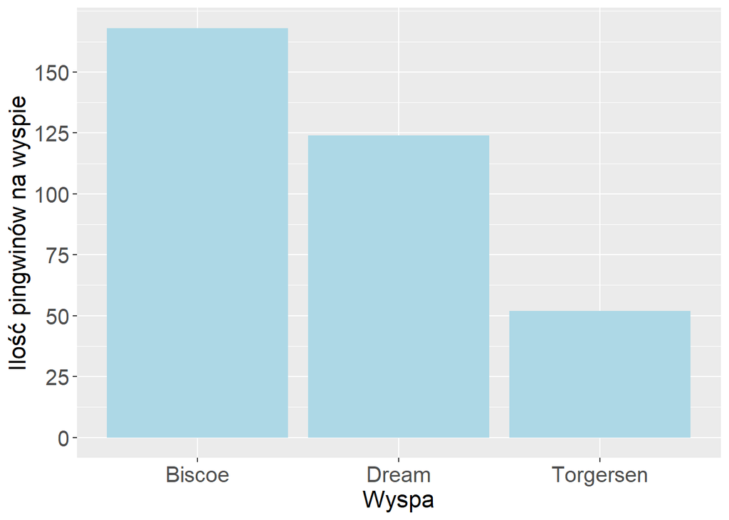

```r
penguins %>%
  ggplot() +
  geom_bar(aes(x = wyspa),fill = "lightblue") +
  scale_y_continuous(breaks = seq(0, 150, by = 25)) +
  theme(axis.text = element_text(size = 15),
        axis.title = element_text(size = 16),
        base_size = 18,
        plot.title = element_text(size = 18)) +
  labs(x = "Wyspa",
       y = "Ilość pingwinów na wyspie")
```

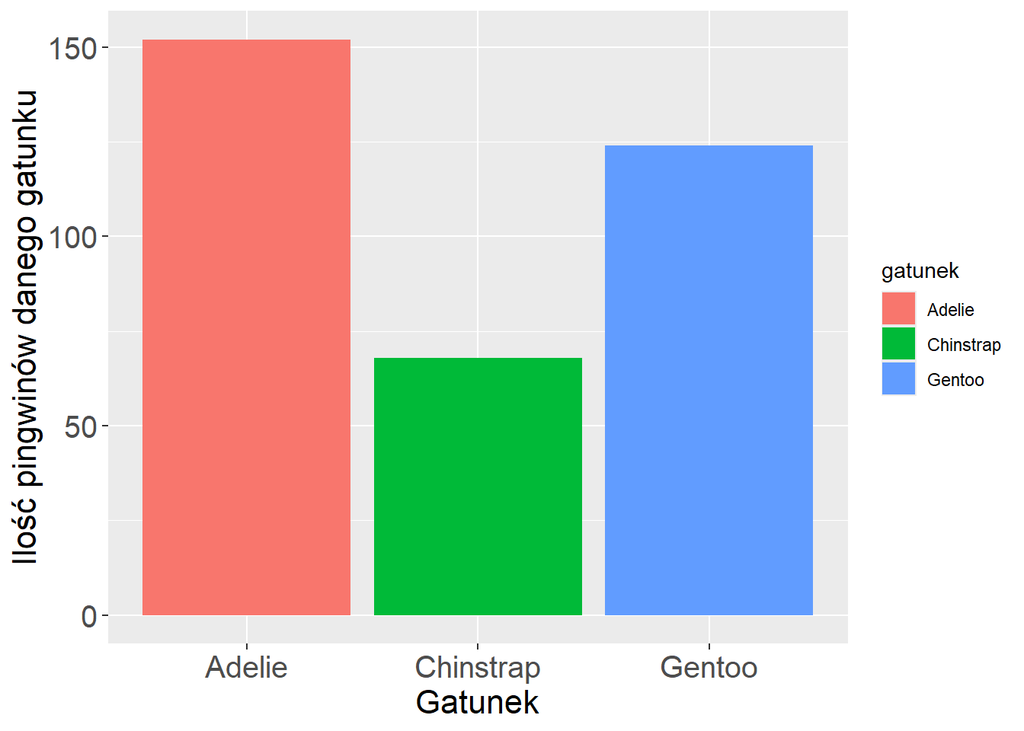

```r
penguins %>%
  ggplot +
  geom_bar(aes(x = gatunek, fill = gatunek)) +
  theme(axis.text = element_text(size = 15),
        axis.title = element_text(size = 16),
        base_size = 18,
        plot.title = element_text(size = 18)) +
  labs(x = "Gatunek",
       y = "Ilość pingwinów danego gatunku")
```

Następnie zobaczmy ile pingwinów poszczególnych gatunków znajduje się na danej wyspie.

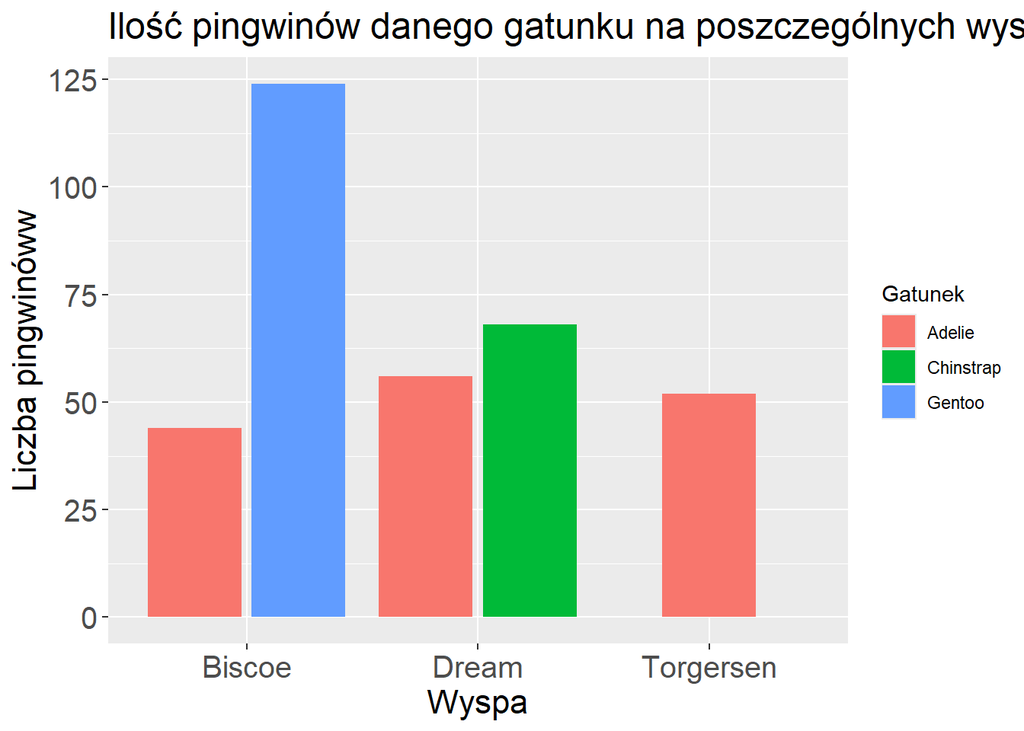

```r
penguins %>%
  ggplot() +
  geom_bar(aes(x = wyspa, fill = gatunek),
           position = position_dodge2(preserve = 'single')) +
  theme(axis.text = element_text(size = 15),
        axis.title = element_text(size = 16),
        base_size = 18,
        plot.title = element_text(size = 18)) +
  scale_y_continuous(breaks = seq(0, 150, by = 25)) +
  labs(title = "Ilość pingwinów danego gatunku na poszczególnych wyspach",
       x = "Wyspa",
       y = "Liczba pingwinóww",
       fill = "Gatunek")
```

Można zauważyć, że Adelie jako jedyne znajdują się na więcej niż jednej wyspie, co więcej znajdują sie na wszystkich trzech. Sprawdźmy więc czy istnieją różnice dla gatunku Adelie pomiędzy poszczególnymi wyspami.

```r
na.omit(penguins[penguins$gatunek == "Adelie", ]) %>%
  group_by(wyspa) %>%
  summarise(srednia_dlugosc_pletwy = mean(dlugosc_pletwy_mm),
            srednia_dlugosc_dzioba = mean(dlugosc_dzioba_mm),
            srednia_wysokosc_dzioba = mean(wysokosc_dzioba_mm),
            srednia_waga = mean(waga_g))
```

```
## # A tibble: 3 × 5
##   wyspa     srednia_dlugosc_pletwy srednia_dlugosc_dzioba
##   <fct>                      <dbl>                  <dbl>
## 1 Biscoe                      189.                   39.0
## 2 Dream                       190.                   38.4
## 3 Torgersen                   192.                   39.1
##   srednia_wysokosc_dzioba srednia_waga
##                     <dbl>        <dbl>
## 1                    18.4        3710.
## 2                    18.2        3685.
## 3                    18.4        3717.
```

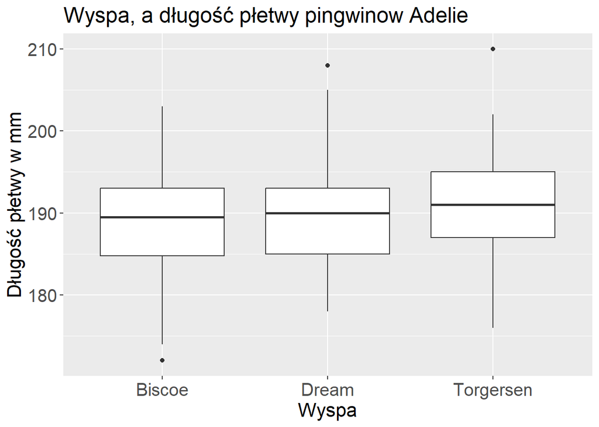

```r
penguins[penguins$gatunek=="Adelie", ] %>%
  ggplot() +
  geom_boxplot(aes(x = wyspa, y = dlugosc_pletwy_mm)) +
  theme(axis.text = element_text(size = 15),
        axis.title = element_text(size = 16),
        base_size = 18,
        plot.title = element_text(size = 18)) +
  labs(title = "Wyspa, a długość płetwy pingwinow Adelie",
       x = "Wyspa",
       y = "Długość płetwy w mm")
```

```r
dunn.test(penguins[penguins$gatunek == "Adelie", ]$dlugosc_pletwy_mm, penguins[penguins$gatunek == "Adelie",]$wyspa)
```

```
##   Kruskal-Wallis rank sum test
##
## data: x and group
## Kruskal-Wallis chi-squared = 3.1482, df = 2, p-value = 0.21
##
##
##                            Comparison of x by group
##                                 (No adjustment)
## Col Mean-|
## Row Mean |     Biscoe      Dream
## ---------+----------------------
##    Dream |  -0.373391
##          |     0.3544
## Torgerse |  -1.655320  -1.370998
##          |     0.0489     0.0852
##
## alpha = 0.05
## Reject Ho if p <= alpha/2
```

```r
dunn.test(penguins[penguins$gatunek == "Adelie", ]$dlugosc_dzioba_mm, penguins[penguins$gatunek == "Adelie",]$wyspa)
```

```
##   Kruskal-Wallis rank sum test
##
## data: x and group
## Kruskal-Wallis chi-squared = 0.7148, df = 2, p-value = 0.7
##
##
##                            Comparison of x by group
##                                 (No adjustment)
## Col Mean-|
## Row Mean |     Biscoe      Dream
## ---------+----------------------
##    Dream |   0.785436
##          |     0.2161
## Torgerse |   0.169027  -0.637803
##          |     0.4329     0.2618
##
## alpha = 0.05
## Reject Ho if p <= alpha/2
```

```r
dunn.test(penguins[penguins$gatunek == "Adelie", ]$wysokosc_dzioba_mm, penguins[penguins$gatunek == "Adelie",]$wyspa)
```

```
##   Kruskal-Wallis rank sum test
##
## data: x and group
## Kruskal-Wallis chi-squared = 0.4691, df = 2, p-value = 0.79
##
##
##                            Comparison of x by group
##                                 (No adjustment)
## Col Mean-|
## Row Mean |     Biscoe      Dream
## ---------+----------------------
##    Dream |   0.589679
##          |     0.2777
## Torgerse |   0.031960  -0.579763
##          |     0.4873     0.2810
##
## alpha = 0.05
## Reject Ho if p <= alpha/2
```

```r
dunn.test(penguins[penguins$gatunek == "Adelie", ]$waga_g, penguins[penguins$gatunek == "Adelie", ]$wyspa)
```

```
##   Kruskal-Wallis rank sum test
##
## data: x and group
## Kruskal-Wallis chi-squared = 0.1665, df = 2, p-value = 0.92
##
##
##                            Comparison of x by group
##                                 (No adjustment)
## Col Mean-|
## Row Mean |     Biscoe      Dream
## ---------+----------------------
##    Dream |   0.407486
##          |     0.3418
## Torgerse |   0.205319  -0.205854
##          |     0.4187     0.4185
##
## alpha = 0.05
## Reject Ho if p <= alpha/2
```

Nie widać istotnych zmian w zależności od wyspy (dodatkowo p-value > 0.025 dla każdego z przypadków). Zobaczmy czy dodatkowy podział na płeć wpłynie na różnicę pomiędzy wyspami.

```r
na.omit(penguins[penguins$gatunek=="Adelie", ]) %>%
  group_by(plec, wyspa) %>%
  summarise(srednia_dlugosc_pletwy = mean(dlugosc_pletwy_mm),
            srednia_dlugosc_dzioba = mean(dlugosc_dzioba_mm),
            srednia_wysokosc_dzioba = mean(wysokosc_dzioba_mm),
            srednia_waga = mean(waga_g))
```

```
## # A tibble: 6 × 6
## # Groups:   plec [2]
##   plec   wyspa     srednia_dlugosc_pletwy srednia_dlugosc_dzioba
##   <fct>  <fct>                      <dbl>                  <dbl>
## 1 female Biscoe                      187.                   37.4
## 2 female Dream                       188.                   36.9
## 3 female Torgersen                   189.                   37.4
## 4 male   Biscoe                      190.                   40.6
## 5 male   Dream                       193.                   40.0
## 6 male   Torgersen                   196.                   40.8
##   srednia_wysokosc_dzioba srednia_waga
##                     <dbl>        <dbl>
## 1                    17.7        3369.
## 2                    17.6        3344.
## 3                    17.5        3391.
## 4                    19.0        4050
## 5                    18.8        4052
## 6                    19.3        4060.
```

Tutaj też niestety nie widać żadnych istotnych zmian w kontekście różnic pomiędzy wyspami. Dalsze rozkładanie grup na pomniejsze czynniki jest niewskazane ze względu na bardzo szybko malejącą ilość rekordów dla poszczególnych grup parametrów (im więcej parametrów tym większy podział na coraz mniejsze grupy). Przy 152 przebadanych okazach (Adelie) należy być w tym wypadku ostrożnym. Poprzedni podział na płeć pomimo, że nie ukazał żadnych istotnych zmian dla Adelie na różnych wyspach daje nam jednak informację, że niezależnie od wyspy wiele parametrów dla płci jest różnych dla płci męskiej oraz żeńskiej wśród pinginów. Zwróćmy zatem uwagę na prosty podział: jak wygląda rozkład płci na poszczególnych wyspach.

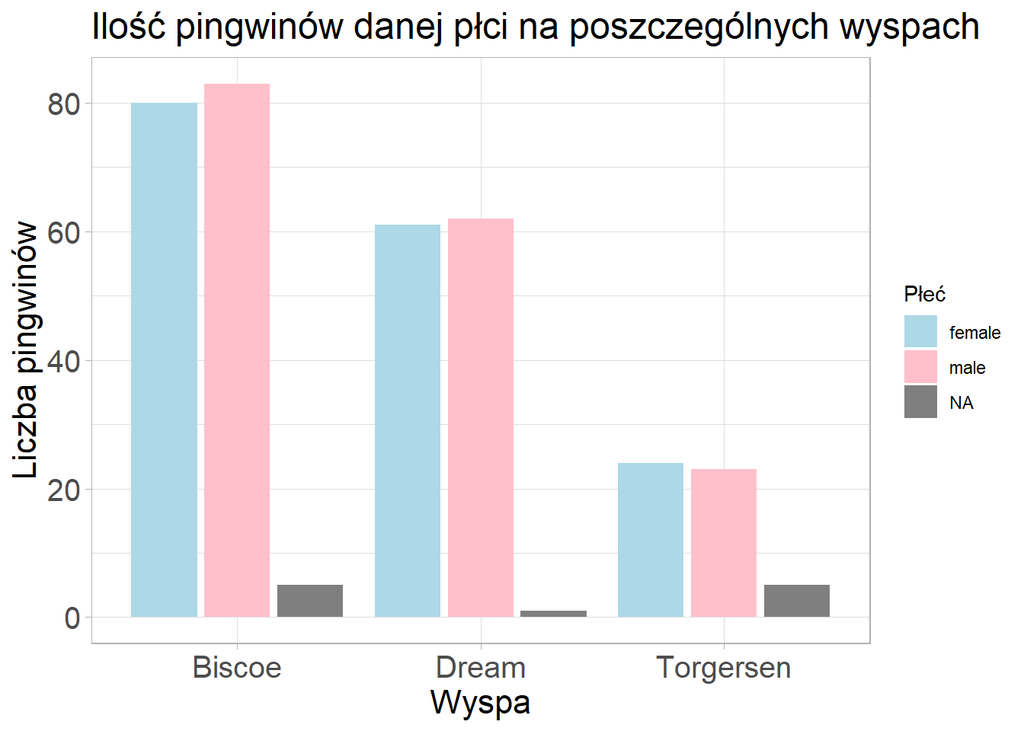

```r
penguins %>%
  ggplot() +
  geom_bar(aes(x = wyspa, fill = plec),
           position = "dodge2") +
  theme_light() +
  theme(axis.text = element_text(size = 15),
        axis.title = element_text(size = 16),
        base_size = 18,
        plot.title = element_text(size = 18)) +
  scale_fill_manual(values=c("lightblue","pink","gray")) +
  labs(title = "Ilość pingwinów danej płci na poszczególnych wyspach",
       x = "Wyspa",
       y = "Liczba pingwinów",
       fill = "Płeć")
```

Tak jak można się było spodziewać podział dla każdej z wysp wynosi około 50/50 dla rodzaju męskiego i żeńskiego. Zobaczmy uogólnione wartości z podziałem tylko i wyłącznie na płeć.

```r
na.omit(penguins) %>%
  group_by(plec) %>%
  summarise(srednia_dlugosc_pletwy=mean(dlugosc_pletwy_mm),
            srednia_dlugosc_dzioba=mean(dlugosc_dzioba_mm),
            srednia_wysokosc_dzioba=mean(wysokosc_dzioba_mm),
            srednia_proporcja_dzioba=mean(proporcja_dzioba),
            srednia_waga=mean(waga_g))
```

```
## # A tibble: 2 × 6
##   plec   srednia_dlugosc_pletwy srednia_dlugosc_dzioba srednia_wysokosc_dzioba
##   <fct>                   <dbl>                  <dbl>                   <dbl>
## 1 female                   198.                   42.1                    16.4
## 2 male                     205.                   46.0                    17.9
##   srednia_proporcja_dzioba srednia_waga
##                      <dbl>        <dbl>
## 1                     2.61        3867.
## 2                     2.62        4565.
```

Jak widać wartości dla płci poza proporcją dzioba nieco się różnią. Zobaczmy w takim razie przykład na wykresach

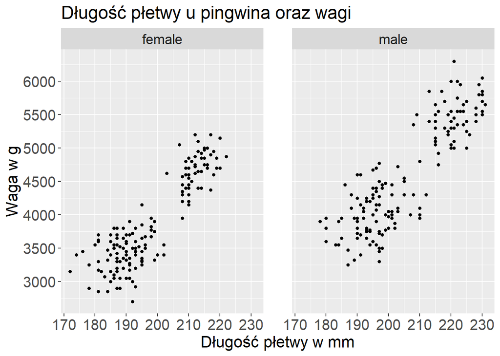

```r
na.omit(penguins) %>%
  ggplot() +
  geom_point(aes(x = dlugosc_pletwy_mm, y = waga_g),
             size = 1.3) +
  facet_wrap(~ plec) +
  theme(axis.text = element_text(size = 15),
        axis.title = element_text(size = 16),
        strip.text = element_text(size = 14),
        base_size = 18,
        panel.spacing = unit(2, "lines"),
        plot.title = element_text(size = 18)) +
  scale_y_continuous(breaks = seq(2500, 6500, by = 500)) +
  labs(title = "Długość płetwy u pingwina oraz wagi",
       x = "Długość płetwy w mm",
       y = "Waga w g")
```

Porównując oba wykresy różnice wartości pomimo tego, że różnice dla wartości dla obu płci nie są duże, są widoczne na wykresie. Spróbujmy wykonać przykładowy test dla różnicy wagi miedzy płciami.

```r
shapiro.test(penguins$waga_g[penguins$plec == "female"])
```

```
##
##  Shapiro-Wilk normality test
##
## data:  penguins$waga_g[penguins$plec == "female"]
## W = 0.91931, p-value = 6.155e-08
```

```r
shapiro.test(penguins$waga_g[penguins$plec == "male"])
```

```
##
##  Shapiro-Wilk normality test
##
## data:  penguins$waga_g[penguins$plec == "male"]
## W = 0.92504, p-value = 1.227e-07
```

Niestety dane nie mają rozkładu normalnego.

```r
wilcox.test(waga_g ~ plec,
            data = penguins,
            alternative = "less")
```

```
##
##  Wilcoxon rank sum test with continuity correction
##
## data:  waga_g by plec
## W = 6874.5, p-value = 9.067e-16
## alternative hypothesis: true location shift is less than 0
```

Wynik testu mówi, o tym, że badane pingwiny płci męskiej są cięższe niż pingwiny płci żeńskiej. Odnosząc się jeszcze do ostatniego wykresu - widać lukę pomiedzy zbiorami danych, wydawałoby się, że istnieje jeszcze jakiś czynnik, który to powoduje. Sprobujmy podzielić te dane jeszcze według gatunku.

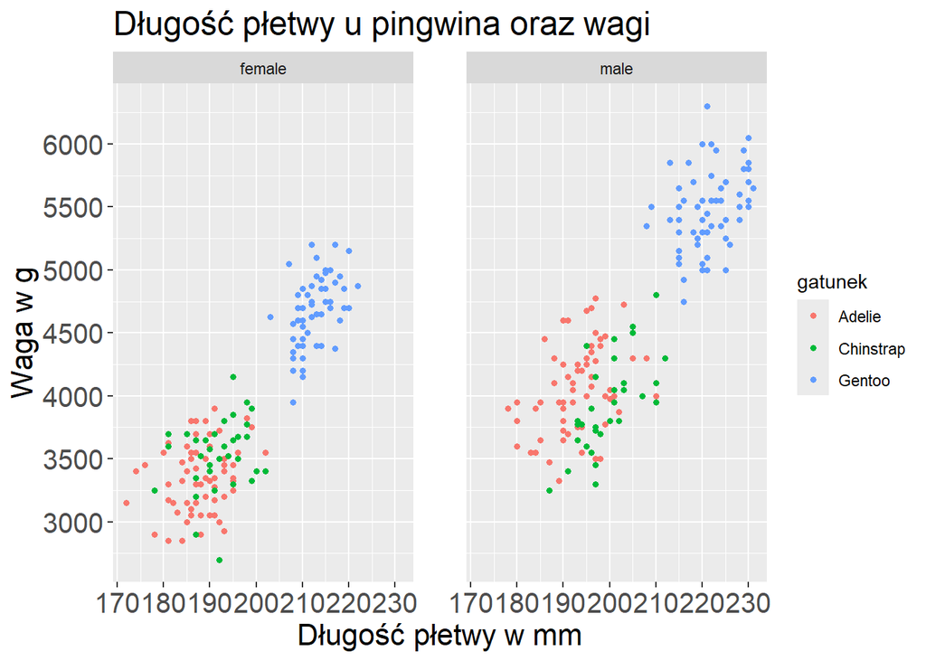

```r
na.omit(penguins) %>%
  ggplot() +
  geom_point(aes(x = dlugosc_pletwy_mm, y = waga_g, color = gatunek),
             size = 1.3) +
  facet_wrap(~ plec) +
  theme(axis.text = element_text(size = 15),
        axis.title = element_text(size = 16),
        base_size = 18,
        panel.spacing = unit(2, "lines"),
        plot.title = element_text(size = 18)) +
  scale_y_continuous(breaks = seq(2500, 6500, by = 500)) +
  labs(title = "Długość płetwy u pingwina oraz wagi",
       x = "Długość płetwy w mm",
       y = "Waga w g")
```

Po podziale dodatkowo na gatunek widać powód dlaczego dane są zróżnicowane. Prawdopodobnie każdy z gatunków ma swoje charakterystyczne cechy - jeden może mieć większy dziób, drugi gatunek może mieć wydłużony dziób, a trzeci mieć dużo większą masę niż pozostałe gatunki. Widać tu jeszcze jedną cechę podziału, którą zajmę się nieco później. Zanim natomiast sprawdzimy różnice gatunkowe oraz wspomnianą cechę zwróćmy uwagę na to czy istnieją jakieś zależności między zmiennymi. Zacznę najpierw bezpiecznie od obliczenia współczynników korelacji rangowej Spearmana dla zmiennych. Skorzystam z tego właśnie współczynnika ze względu na to, że w poprzedniej próbie ukazała się duża luka pomiędzy danymi oraz bardzo istotny był podział pomiędzy gatunkami.

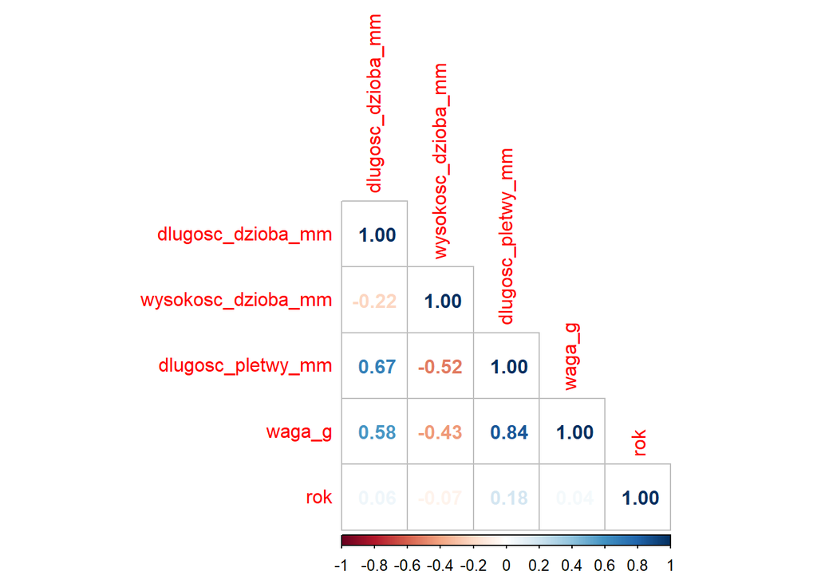

```r
cor=round(cor(na.omit(penguins[,c("dlugosc_dzioba_mm", "wysokosc_dzioba_mm",
                                  "dlugosc_pletwy_mm", "waga_g", "rok")]),
                                   method = "spearman"),2)
corrplot(cor, method = "number", type = "lower")
```

[figure not shown]

```r
na.omit(penguins) %>%
  ggplot() +
  geom_point(aes(x = waga_g, y = dlugosc_pletwy_mm),
             size = 2,
             color = "lightblue") +
  theme_light(base_size = 14) +
  theme(axis.text = element_text(size = 15),
        axis.title = element_text(size = 16),
        base_size = 18,
        plot.title = element_text(size = 18)) +
  labs(title = "Wykres długosci płetwy u pingwinów oraz ich wagi",
       x = "Długość płetwy w mm",
       y = "Waga w g")
```

Bardzo dobrze widać na powyższym wykresie wzrost wagi przy wzroście długości płetwy dla pingwinów. Zobaczmy w takim razie jak wygląda jedna z zależności z ujemnym współczynnikiem korelacji.

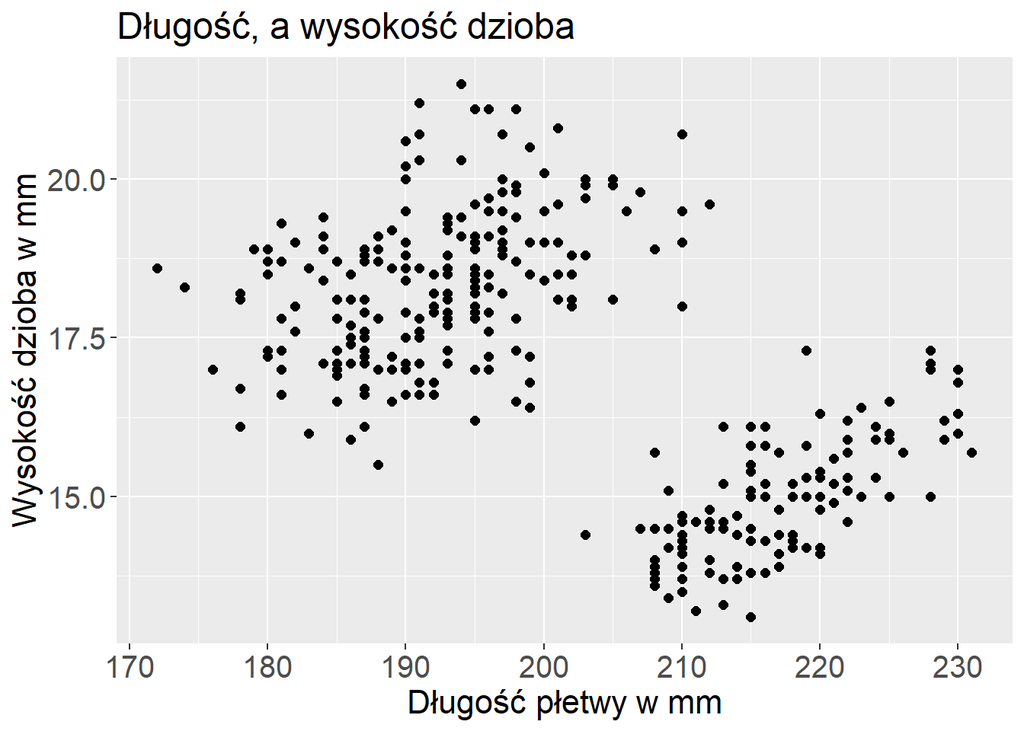

```r
penguins %>%
  ggplot() +
  geom_point(aes(x = dlugosc_pletwy_mm, y = wysokosc_dzioba_mm),
             size = 2) +
  theme(axis.text = element_text(size = 15),
        axis.title = element_text(size = 16),
        base_size = 18,
        plot.title = element_text(size = 18)) +
  labs(title = "Długość, a wysokość dzioba",
       x = "Długość płetwy w mm",
       y = "Wysokość dzioba w mm")
```

Patrząc na dane ukazane na wykresie powstają niestety dwa problemy: pierwszym jest widoczna luka w danych, a drugim jest brak oczywistej zależności liniowej. Ponownie spróbujmy podzielić ten wykres na gatunki.

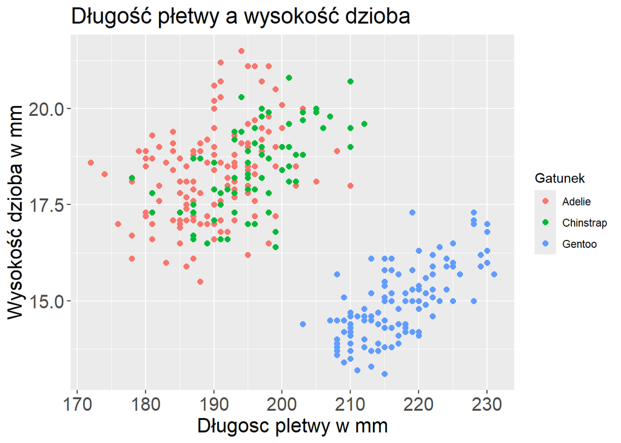

```r
penguins %>%
  ggplot() +
  geom_point(aes(x = dlugosc_pletwy_mm, y = wysokosc_dzioba_mm, color=gatunek),
             size = 2) +
  theme(axis.text = element_text(size = 15),
        axis.title = element_text(size = 16),
        base_size = 18,
        plot.title = element_text(size = 18)) +
  labs(title = "Długość płetwy a wysokość dzioba",
       x = "Długosc pletwy w mm",
       y = "Wysokość dzioba w mm",
       color="Gatunek")
```

```r
na.omit(penguins) %>%
  group_by(gatunek)%>%
  summarise(korelacja = cor(dlugosc_pletwy_mm, wysokosc_dzioba_mm, method = "pearson"))
```

```
## # A tibble: 3 × 2
##   gatunek   korelacja
##   <fct>         <dbl>
## 1 Adelie        0.329
## 2 Chinstrap     0.572
## 3 Gentoo        0.711
```

Współczynniki przy podziale na konkretne grupy wyglądają już zupełnie inaczej. Z pewną dozą niepewności można stwierdzić, że sytuacja jest odwrotna do wcześniej oczekiwanej - przy wzroście długości płetwy u pingwinów bardzo często wysokość dzioba również się zwiększa. Kolejnym aspektem na który chciałbym zwrócić uwagę jest wspomnianą przeze mnie wcześniej różnicę przy podziale na płci. U męskich osobników m.in. gatunku Adelie na wykresie “Długość płetwy u pingwina oraz wagi” można zauważyć nieco większe rozproszenie wartości niż u płci przeciwnej.

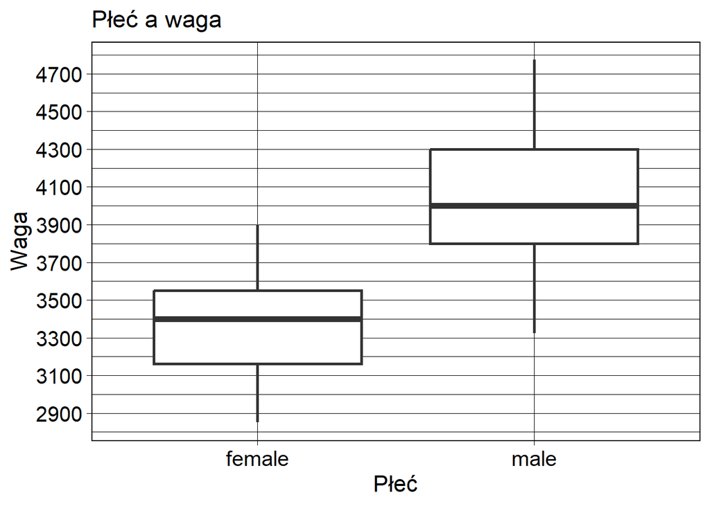

```r
na.omit(penguins[penguins$gatunek=="Adelie",]) %>%
  ggplot() +
  geom_boxplot(aes(x = plec, y = waga_g),
                   size = 1) +
  scale_y_continuous(breaks = seq(2700, 5500, by = 200)) +
  theme_linedraw(base_size = 14) +
  theme(axis.text = element_text(size = 15),
        axis.title = element_text(size = 16)) +
  labs(title = "Płeć a waga",
       x = "Płeć",
       y = "Waga",
       color="Gatunek")
```

```r
na.omit(penguins)%>%
  group_by(plec) %>%
  summarise(`odchylenie standardowe` = sd(waga_g))
```

```
## # A tibble: 2 × 2
##   plec   `odchylenie standardowe`
##   <fct>                     <dbl>
## 1 female                     668.
## 2 male                       790.
```

Na wykresie widać, że zarówno pudełko jak i wąsy dla płci męskiej są nieco bardziej wydłużone niż dla płci żeńskiej. Różnice widać też w wartości odchylenia standardowego dla wagi. Odnosząc się dalej do płci chciałbym sprawdzić jeszcze jedną zależność - czy poziom azotu wykryty u pingwinów jest u obu płci taki sam. Zacznijmy od prostej wizualizacji.

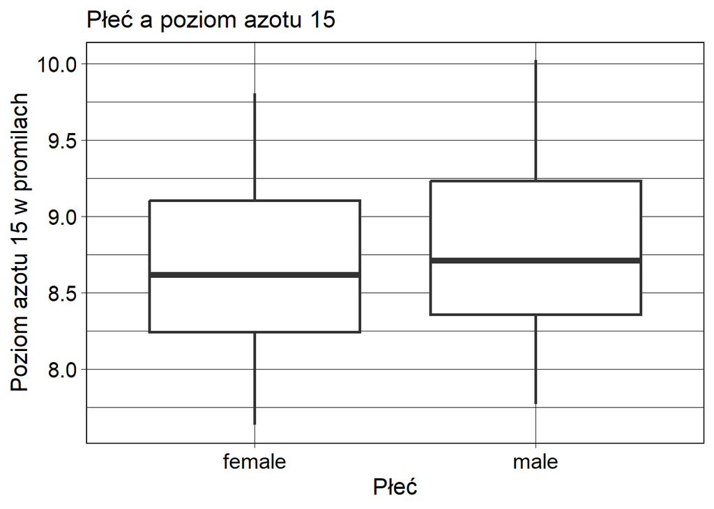

```r
na.omit(penguins) %>%
  ggplot() +
  geom_boxplot(aes(x = plec, y = delta15N),
                   size = 1) +
  theme_linedraw(base_size = 14) +
  theme(axis.text = element_text(size = 15),
        axis.title = element_text(size = 16)) +
  labs(title = "Płeć a poziom azotu 15",
       x = "Płeć",
       y = "Poziom azotu 15 w promilach")
```

```r
shapiro.test(penguins$delta15N[penguins$plec == "male"])
```

```
##
##  Shapiro-Wilk normality test
##
## data:  penguins$delta15N[penguins$plec == "male"]
## W = 0.97119, p-value = 0.001921
```

```r
shapiro.test(penguins$delta15N[penguins$plec == "female"])
```

```
##
##  Shapiro-Wilk normality test
##
## data:  penguins$delta15N[penguins$plec == "female"]
## W = 0.97588, p-value = 0.006004
```

Niestety dane nie pochodzą z rozkładu normalnego.

```r
dunn.test(penguins$delta15N, penguins$plec)
```

```
##   Kruskal-Wallis rank sum test
##
## data: x and group
## Kruskal-Wallis chi-squared = 3.6674, df = 1, p-value = 0.06
##
##
##                            Comparison of x by group
##                                 (No adjustment)
## Col Mean-|
## Row Mean |     female
## ---------+-----------
##     male |  -1.915050
##          |     0.0277
##
## alpha = 0.05
## Reject Ho if p <= alpha/2
```

Wynik testu wskazuje na to, że nie występują istotne różnice pomiędzy płciami w poziomie azotu 15. Ostatnią rzeczą, którą chciałbym sprawdzić jest to czy istnieje różnica w podłużności dziobów u różnych gatunków.

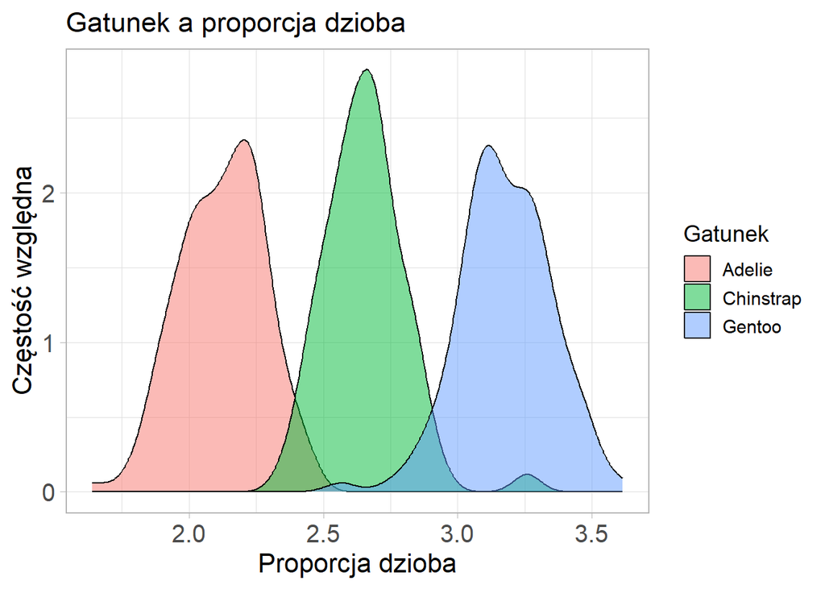

```r
na.omit(penguins) %>%
  group_by(gatunek) %>%
  ggplot() +
  geom_density(aes(x = proporcja_dzioba, fill=gatunek),
               linewidth = 0.5,
               alpha = 0.5) +
  labs(title = "Gatunek a proporcja dzioba",
       x = "Proporcja dzioba",
       y = "Częstość względna",
       fill = "Gatunek") +
  theme_light(base_size = 14) +
  theme(axis.text = element_text(size = 15),
        axis.title = element_text(size = 16))
```

```r
shapiro.test(penguins$proporcja_dzioba[penguins$gatunek == "Adelie"])
```

```
##
##  Shapiro-Wilk normality test
##
## data:  penguins$proporcja_dzioba[penguins$gatunek == "Adelie"]
## W = 0.99029, p-value = 0.3864
```

```r
shapiro.test(penguins$proporcja_dzioba[penguins$gatunek == "Gentoo"])
```

```
##
##  Shapiro-Wilk normality test
##
## data:  penguins$proporcja_dzioba[penguins$gatunek == "Gentoo"]
## W = 0.98856, p-value = 0.3962
```

```r
shapiro.test(penguins$proporcja_dzioba[penguins$gatunek == "Chinstrap"])
```

```
##
##  Shapiro-Wilk normality test
##
## data:  penguins$proporcja_dzioba[penguins$gatunek == "Chinstrap"]
## W = 0.9515, p-value = 0.01007
```

Niestety założenie p-value>0.05 nie jest spełnione.

```r
dunn.test(penguins$proporcja_dzioba, penguins$gatunek)
```

```
##   Kruskal-Wallis rank sum test
##
## data: x and group
## Kruskal-Wallis chi-squared = 289.5803, df = 2, p-value = 0
##
##
##                            Comparison of x by group
##                                 (No adjustment)
## Col Mean-|
## Row Mean |     Adelie   Chinstra
## ---------+----------------------
## Chinstra |  -7.718621
##          |    0.0000*
##   Gentoo |  -16.95095  -6.164955
##          |    0.0000*    0.0000*
##
## alpha = 0.05
## Reject Ho if p <= alpha/2
```

Wyniki testu mówią, że należy odrzucić hipotezę, aby te gatunki były statystycznie podobne jeśli chodzi, o podłużność dzioba - różnią się one istotnie.